R Project: Chapter 14 Baker, Ceridwen Math M15H, Fall 2020

```r
# Load the germane libraries
library(tidyverse)
library(faraway)
```

```r
# Load and check out the data from the Faraway package.
dat <- data.frame(uswages)
glimpse(dat)
```

```
## Rows: 2,000
## Columns: 10
## $ wage  <dbl> 771.60, 617.28, 957.83, 617.28, 902.18, 299.15, 541.31, 148.39,…
## $ educ  <int> 18, 15, 16, 12, 14, 12, 16, 16, 12, 12, 9, 14, 17, 14, 14, 10, …
## $ exper <int> 18, 20, 9, 24, 12, 33, 42, 0, 36, 37, 20, 29, 16, 21, 11, 10, 8…
## $ race  <int> 0, 0, 0, 0, 0, 0, 0, 0, 0, 0, 1, 0, 0, 0, 0, 0, 0, 0, 0, 0, 0, …
## $ smsa  <int> 1, 1, 1, 1, 1, 1, 1, 1, 1, 0, 1, 1, 0, 1, 0, 1, 0, 1, 1, 1, 0, …
## $ ne    <int> 1, 0, 0, 1, 0, 0, 0, 0, 0, 0, 0, 0, 1, 0, 0, 0, 0, 0, 1, 0, 0, …
## $ mw    <int> 0, 0, 0, 0, 1, 0, 0, 1, 0, 1, 0, 0, 0, 0, 1, 0, 0, 0, 0, 0, 0, …
## $ so    <int> 0, 0, 1, 0, 0, 0, 1, 0, 0, 0, 1, 1, 0, 0, 0, 0, 1, 1, 0, 1, 1, …
## $ we    <int> 0, 1, 0, 0, 0, 1, 0, 0, 1, 0, 0, 0, 0, 1, 0, 1, 0, 0, 0, 0, 0, …
## $ pt    <int> 0, 0, 0, 0, 0, 0, 1, 1, 1, 0, 1, 0, 0, 1, 0, 0, 0, 0, 0, 0, 0, …
```

```r
view(dat)
```

1a. Create a scatterplot with the regression line for experience vs. wage.

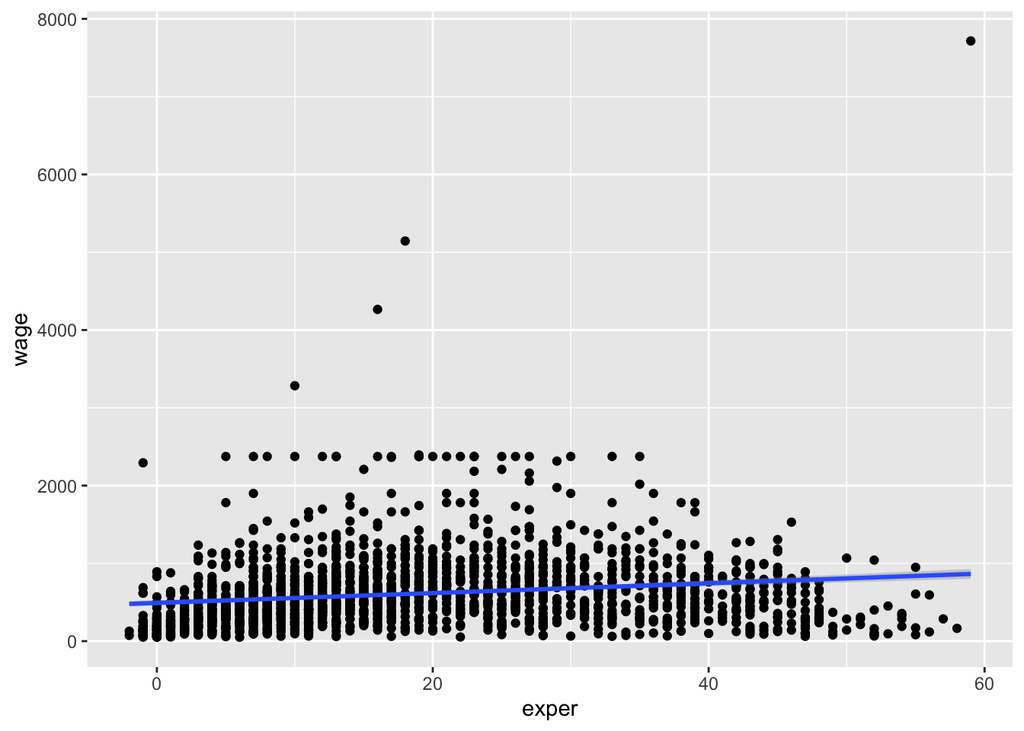

```r
ggplot(data=dat, aes(x=exper, y=wage))+geom_point()+geom_smooth(method = lm)
```

1b. Create a scatterplot with the regression line for education vs. wage.

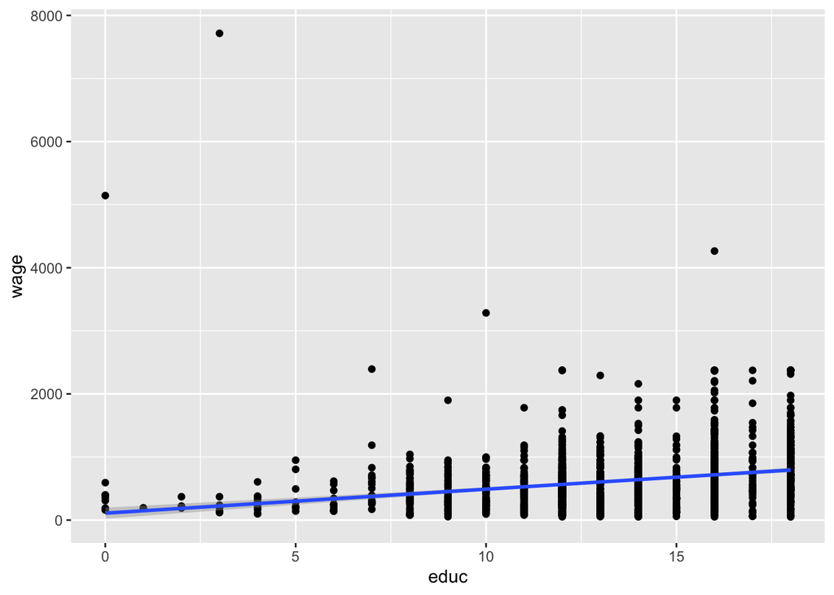

```r
ggplot(data=dat, aes(x=educ, y=wage))+geom_point()+geom_smooth(method = lm)
```

2a. Save the linear model for wage ~ experience as mod1.

```r
mod1 <- lm(wage ~ exper, data=dat)
mod1
```

```
##
## Call:
## lm(formula = wage ~ exper, data = dat)
##
## Coefficients:
## (Intercept)        exper
##     492.167        6.298
```

2b. Save the summary of mod1 as mod1_sum. Print the summary.

```r
mod1_sum <- summary(mod1)
mod1_sum
```

```
##
## Call:
## lm(formula = wage ~ exper, data = dat)
##
## Residuals:
##    Min     1Q Median     3Q    Max
## -755.5 -271.0  -77.5  165.7 6852.3
##
## Coefficients:
##             Estimate Std. Error t value Pr(>|t|)
## (Intercept) 492.1669    17.2043   28.61   <2e-16 ***
## exper         6.2981     0.7561    8.33   <2e-16 ***
## ---
## Signif. codes:  0 '***' 0.001 '**' 0.01 '*' 0.05 '.' 0.1 ' ' 1
##
## Residual standard error: 452.2 on 1998 degrees of freedom
## Multiple R-squared:  0.03356,    Adjusted R-squared:  0.03308
## F-statistic: 69.39 on 1 and 1998 DF,  p-value: < 2.2e-16
```

3a. Save the linear model for wage ~ education as mod2.

```r
mod2 <- lm(wage ~ educ, data=dat)
mod2
```

```
##
## Call:
## lm(formula = wage ~ educ, data = dat)
##
## Coefficients:
## (Intercept)         educ
##      109.75        38.01
```

3b. Save the summary of mod2 as mod2_sum. Print the summary.

```r
mod2_sum <- summary(mod2)
mod2_sum
```

```
##
## Call:
## lm(formula = wage ~ educ, data = dat)
##
## Residuals:
##    Min     1Q Median     3Q    Max
## -743.6 -269.5  -67.7  173.0 7492.3
##
## Coefficients:
##             Estimate Std. Error t value Pr(>|t|)
## (Intercept)  109.754     44.616    2.46    0.014 *
## educ          38.011      3.317   11.46   <2e-16 ***
## ---
## Signif. codes:  0 '***' 0.001 '**' 0.01 '*' 0.05 '.' 0.1 ' ' 1
##
## Residual standard error: 445.5 on 1998 degrees of freedom
## Multiple R-squared:  0.06167,    Adjusted R-squared:  0.0612
## F-statistic: 131.3 on 1 and 1998 DF,  p-value: < 2.2e-16
```

4a. Now create a quadratic regression curve for experience and wage. Call this mod3. Print the summary.

```r
mod3 <- lm(wage ~ I(exper^2) + I(exper),dat)
summary(mod3)
```

```
##
## Call:
## lm(formula = wage ~ I(exper^2) + I(exper), data = dat)
##
## Residuals:
##    Min     1Q Median     3Q    Max
## -706.2 -239.1  -77.7  143.1 7537.2
##
## Coefficients:
##             Estimate Std. Error t value Pr(>|t|)
## (Intercept) 293.8243    23.3830   12.57   <2e-16 ***
## I(exper^2)   -0.6160     0.0511  -12.05   <2e-16 ***
## I(exper)     34.3964     2.4426   14.08   <2e-16 ***
## ---
## Signif. codes:  0 '***' 0.001 '**' 0.01 '*' 0.05 '.' 0.1 ' ' 1
##
## Residual standard error: 436.7 on 1997 degrees of freedom
## Multiple R-squared:  0.09912,    Adjusted R-squared:  0.09822
## F-statistic: 109.9 on 2 and 1997 DF,  p-value: < 2.2e-16
```

4b. Does having the quadratic term help give a better model? Explain and justify your answer. The quadratic has a better model because the goodness of fit is better in the quadratic than in the linear. the linear has a 0.033 and the quadratic has a 0.098.

5a. Now create a model with education and wage as predictors and wage as the response variable. Call this mod4. Print its summary.

```r
mod4 <- lm(wage ~  educ + wage, dat)
summary(mod4)
```

```
##
## Call:
## lm(formula = wage ~ educ + wage, data = dat)
##
## Residuals:
##    Min     1Q Median     3Q    Max
## -743.6 -269.5  -67.7  173.0 7492.3
##
## Coefficients:
##             Estimate Std. Error t value Pr(>|t|)
## (Intercept)  109.754     44.616    2.46    0.014 *
## educ          38.011      3.317   11.46   <2e-16 ***
## ---
## Signif. codes:  0 '***' 0.001 '**' 0.01 '*' 0.05 '.' 0.1 ' ' 1
##
## Residual standard error: 445.5 on 1998 degrees of freedom
## Multiple R-squared:  0.06167,    Adjusted R-squared:  0.0612
## F-statistic: 131.3 on 1 and 1998 DF,  p-value: < 2.2e-16
```

5b. Now create a model with education and experience as predictors and wage as the response variable. Also include an interaction variable of education and experience. Call this mod5. Print its summary.

```r
mod5 <- lm(wage ~  educ + exper, dat)
summary(mod5)
```

```
##
## Call:
## lm(formula = wage ~ educ + exper, data = dat)
##
## Residuals:
##     Min      1Q  Median      3Q     Max
## -1018.2  -237.9   -50.9   149.9  7228.6
##
## Coefficients:
##              Estimate Std. Error t value Pr(>|t|)
## (Intercept) -242.7994    50.6816  -4.791 1.78e-06 ***
## educ          51.1753     3.3419  15.313  < 2e-16 ***
## exper          9.7748     0.7506  13.023  < 2e-16 ***
## ---
## Signif. codes:  0 '***' 0.001 '**' 0.01 '*' 0.05 '.' 0.1 ' ' 1
##
## Residual standard error: 427.9 on 1997 degrees of freedom
## Multiple R-squared:  0.1351, Adjusted R-squared:  0.1343
## F-statistic:   156 on 2 and 1997 DF,  p-value: < 2.2e-16
```

6. Please rank mod1, mod2, mod3, mod4, and mod5 from best to worst. Explain and justify your answer in detail.

1.mod5 2.mod3 3.mod2 4.mod1 5.mod4 mod 4 dosent make sence because having wage as a predictor and a response variable makes no sense so it is last. I ordered 1-3 ad 5 the way they are based on the r squared value. mod 5 has the largest at .1343 next is mod3 at 0.09822 then mod2 at 0.0612 and then mod1 at 0.03308.